# Can the Great Eight Catch the Great One?

by Erin Lea

## Introduction

Wayne Gretzky ("the Great One") is widely regarded as the greatest National Hockey League (NHL) player of all time. During his career (1979-1999), he set many NHL records, holding 61 at his retirement, including those for most goals scored, most assists produced, and most points scored across his career. He still holds all three of those records today, 23 years after his retirement.

Alexander Ovechkin ("the Great Eight") is the current captain of the Washington Capitals and, as of May 14th, 2021, is the number six goal scorer in NHL history, the top among all active players. His rankings for assists and points (98 and 35, respectively) are less impressive, but there has been talk for quite a while in the hockey community about how far up in the goals rankings he will ascend by his retirement.

The breadth of Gretzky's achievements over the course of his career makes him difficult to compare to any other player in NHL history, and I agree that his like will almost certainly never be seen again. In this tutorial, I will not attempt to compare Ovechkin to Gretzky in his totality. Rather, I will investigate the possibility of Ovechkin taking Gretky's goal record by the time he retires. For additional breadth, I will also analyze the trajectory of Ovechkin's assists and points records, but I will mainly focus on goals.

## Setup

I will be using the following libraries in this tutorial:

```python
# For getting the webpages that contain the data:
import requests
# For parsing HTML from the webpages to get data:
from bs4 import BeautifulSoup
# For storing and managing the data:
import pandas as pd
# For NaN and reshaping lists:
import numpy as np
# For plotting:
import matplotlib.pyplot as plt
# For linear regression:
from sklearn.linear_model import LinearRegression
```

## Our Dataset

### Getting the Data

Goals, assists, and points are all stored on separate webpages, so we will scrape the data from all three pages and store them in one table. I am choosing to manage the data using pandas dataframes. pandas is a Python library for data management that makes data access and modification simple. It's not very difficult to pick up, which is why I think it serves well in a tutorial setting. Requests and BeautifulSoup are two other useful libraries for getting data from webpages. Their purposes are described in the comments when they are imported above.

```python
# Use requests to get the HTML for the three webpages that the stats are stored on.
goals_html = requests.get('https://www.hockey-reference.com/leaders/goals_career.html')
assists_html = requests.get('https://www.hockey-reference.com/leaders/assists_career.html')
points_html = requests.get('https://www.hockey-reference.com/leaders/points_career.html')

# Use BeautifulSoup to create parsers for each of the above HTML files.
goals_data = BeautifulSoup(goals_html.text, 'html.parser')
assists_data = BeautifulSoup(assists_html.text, 'html.parser')
points_data = BeautifulSoup(points_html.text, 'html.parser')

# Use the parsers to get the data tables from each HTML file.
goals_table = goals_data.find('table')
assists_table = assists_data.find('table')
points_table = points_data.find('table')
```

Note: the webpages I'm using have two tables: one for NHL records, one for WHA records. The BeautifulSoup find() method gets the first element with the given tag by default, so we can just use find('table') to get the first table, which is the one we're looking for. If the NHL table came second, we would use find_all('table') and then use the second table in the list of tables returned.

Next, we're going to read the tables for each record into their own pandas dataframe. Notice that we're calling the one for goals 'leaders' -- I'll explain that in a minute.

```python
# Read each table into its own dataframe.
leaders = pd.read_html(str(goals_table))[0]
assists = pd.read_html(str(assists_table))[0]
points = pd.read_html(str(points_table))[0]
```

Let's see what the goals table looks like on its own.

```python
leaders.head()
```

|  | Rank | Player | Years | G |
| --- | --- | --- | --- | --- |
| 0 | 1.0 | Wayne Gretzky* | 1979-99 | 894 |
| 1 | 2.0 | Gordie Howe* | 1946-80 | 801 |
| 2 | 3.0 | Jaromir Jagr | 1990-18 | 766 |
| 3 | 4.0 | Brett Hull* | 1986-06 | 741 |
| 4 | 5.0 | Marcel Dionne* | 1971-89 | 731 |

Now, we're going to take the assists and points columns from their respective tables and add them to the end of the goals table. This is why we called goals table 'leaders' -- now, it reflects NHL leaders across three different metrics. We'll initialize each column to NaN, since there may be leaders in assists or points that aren't goals leaders. Rather than saying that those players had zero goals, we'll use NaN to represent that we don't have their goals data.

```python
# Add assists data to leaders table.

# Create assists column in leaders (initialized to NaN).
leaders['A'] = np.nan
# Add assists data to table.
for index, row in assists.iterrows():
    # If the given player in the assists table is already in leaders, add their assists data to their row.
    if row['Player'] in leaders.values:
        index = leaders.loc[leaders['Player'] == row['Player']].index
        leaders.loc[index, 'A'] = row['A']
    # If not, create a new row for the player in the leaders table and set their rank and goals values to NaN
    # (we don't have their goals data, and their goals rank is irrelevant).
    else:
        leaders = leaders.append({'Rank':np.nan, 'Player':row['Player'], 'Years':row['Years'],
                                  'G':np.nan, 'A':row['A']}, ignore_index=True)

# Add points data to leaders table using the same process.

# Create points column in leaders (initialized to NaN).
leaders['P'] = np.nan
# Add points data to table.
for index, row in points.iterrows():
    # If the given player in the points table is already in leaders, add their points data to their row.
    if row['Player'] in leaders.values:
        index = leaders.loc[leaders['Player'] == row['Player']].index
        leaders.loc[index, 'P'] = row['PTS']
    # If not, create a new row for the player in the leaders table and set their rank, goals, and assists values to
    # NaN (we don't have their goals or assists data, and their goals rank is irrelevant).
    else:
        leaders = leaders.append({'Rank':np.nan, 'Player':row['Player'], 'Years':row['Years'],
                                  'G':np.nan, 'A':np.nan, 'P':row['PTS']}, ignore_index=True)
```

Let's see what the leaders table looks like with all three metrics.

```python
leaders.head()
```

|  | Rank | Player | Years | G | A | P |
| --- | --- | --- | --- | --- | --- | --- |
| 0 | 1.0 | Wayne Gretzky* | 1979-99 | 894.0 | 1963.0 | 2857.0 |
| 1 | 2.0 | Gordie Howe* | 1946-80 | 801.0 | 1049.0 | 1850.0 |
| 2 | 3.0 | Jaromir Jagr | 1990-18 | 766.0 | 1155.0 | 1921.0 |
| 3 | 4.0 | Brett Hull* | 1986-06 | 741.0 | 650.0 | 1391.0 |
| 4 | 5.0 | Marcel Dionne* | 1971-89 | 731.0 | 1040.0 | 1771.0 |

### Tidying the Data

Right away, I notice something that should be fixed. 'Rank' no longer makes sense to have, since the table now has data beyond just one metric. Let's remove it.

```python
# Drop the 'rank' column from leaders (axis=1 specifies that it's a column).
leaders = leaders.drop(['Rank'], axis=1)
leaders.head()
```

|  | Player | Years | G | A | P |
| --- | --- | --- | --- | --- | --- |
| 0 | Wayne Gretzky* | 1979-99 | 894.0 | 1963.0 | 2857.0 |
| 1 | Gordie Howe* | 1946-80 | 801.0 | 1049.0 | 1850.0 |
| 2 | Jaromir Jagr | 1990-18 | 766.0 | 1155.0 | 1921.0 |
| 3 | Brett Hull* | 1986-06 | 741.0 | 650.0 | 1391.0 |
| 4 | Marcel Dionne* | 1971-89 | 731.0 | 1040.0 | 1771.0 |

From now on, we can sort the dataframe by G, A, or P if we want to see player standings for a specific metric. Right now, it's still sorted by goals.

The website that the data was scraped from says that an asterisk next to a player's name represents membership in the Hockey Hall of Fame. We don't need those, so let's remove them.

```python
# Check each player name in leaders.
for index, row in leaders.iterrows():
    player = row['Player']
    # If the player name has an asterisk, remove the last character in the name (the asterisk).
    if '*' in player:
        leaders.loc[index, 'Player'] = player[0:len(player) - 1]

leaders.head()
```

|  | Player | Years | G | A | P |
| --- | --- | --- | --- | --- | --- |
| 0 | Wayne Gretzky | 1979-99 | 894.0 | 1963.0 | 2857.0 |
| 1 | Gordie Howe | 1946-80 | 801.0 | 1049.0 | 1850.0 |
| 2 | Jaromir Jagr | 1990-18 | 766.0 | 1155.0 | 1921.0 |
| 3 | Brett Hull | 1986-06 | 741.0 | 650.0 | 1391.0 |
| 4 | Marcel Dionne | 1971-89 | 731.0 | 1040.0 | 1771.0 |

## Exploratory Analysis

Exploratory analysis in data science is often used to look at the data in different ways and see what is happening before we make any assumptions. Since we are looking at how far Ovechkin can go with his stats by the end of his career, it might help us to plot players' stats by the number of years they spent in the NHL. We don't currently have a seasons column in our dataframe. Let's make one from the years column that we already have.

```python
# Create Seasons column in leaders (initialized to 0).
leaders['Seasons'] = 0

# Calculate Seasons for each player based on Years
for index, row in leaders.iterrows():
    # Get starting year.
    start = int(row['Years'][0:4])

    # Get last two digits of ending year.
    end = int(row['Years'][5:7])

    # Figure out the century of the ending year by looking at the starting year.
    # (Additional information: the NHL's first season was in 1917, and we can safely say that no one in NHL
    # history has had a 100-year career.)
    if end <= 21 and start > 1921:
        # Ending year is in the 2000s.
        end += 2000
    else:
        # Ending year is in the 1900s.
        end += 1900

    # Get season from starting and ending year and add it to leaders.
    leaders.loc[index, 'Seasons'] = end - start

leaders.head()
```

|  | Player | Years | G | A | P | Seasons |
| --- | --- | --- | --- | --- | --- | --- |
| 0 | Wayne Gretzky | 1979-99 | 894.0 | 1963.0 | 2857.0 | 20 |
| 1 | Gordie Howe | 1946-80 | 801.0 | 1049.0 | 1850.0 | 34 |
| 2 | Jaromir Jagr | 1990-18 | 766.0 | 1155.0 | 1921.0 | 28 |
| 3 | Brett Hull | 1986-06 | 741.0 | 650.0 | 1391.0 | 20 |
| 4 | Marcel Dionne | 1971-89 | 731.0 | 1040.0 | 1771.0 | 18 |

Now that we have the number of seasons for each player, we can make scatter plots for statistic by number of seasons for goals, assists, and points.

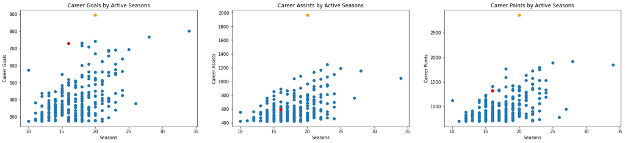

```python
# Make three subplots.
plt.subplots(figsize=(25,5))

# Get rows for Gretzky and Ovechkin so we can highlight them in the plots.
gretzky = leaders[leaders['Player'] == 'Wayne Gretzky']
ovechkin = leaders[leaders['Player'] == 'Alex Ovechkin']

# Make first scatter plot for goals versus seasons.
plt.subplot(1, 3, 1)
plt.scatter(leaders['Seasons'], leaders['G'])
plt.scatter(gretzky['Seasons'], gretzky['G'], color='orange')
plt.scatter(ovechkin['Seasons'], ovechkin['G'], color='red')
plt.title('Career Goals by Active Seasons')
plt.xlabel('Seasons')
plt.ylabel('Career Goals')

# Make second scatter plot for assists versus seasons.
plt.subplot(1, 3, 2)
plt.scatter(leaders['Seasons'], leaders['A'])
plt.scatter(gretzky['Seasons'], gretzky['A'], color='orange')
plt.scatter(ovechkin['Seasons'], ovechkin['A'], color='red')
plt.title('Career Assists by Active Seasons')
plt.xlabel('Seasons')
plt.ylabel('Career Assists')

# Make third scatter plot for points versus seasons.
plt.subplot(1, 3, 3)
plt.scatter(leaders['Seasons'], leaders['P'])
plt.scatter(gretzky['Seasons'], gretzky['P'], color='orange')
plt.scatter(ovechkin['Seasons'], ovechkin['P'], color='red')
plt.title('Career Points by Active Seasons')
plt.xlabel('Seasons')
plt.ylabel('Career Points')

# Show the plots.
plt.show()
```

In the above plots, Gretzky is highlighted in orange (for the Edmonton Oilers) and Ovechkin is highlighted in red (for the Washington Capitals). We can see that Gretzky is far above all of other leaders at and beyond the twenty-season mark, especially in terms of assists and points. This is why I said in the introduction that I'm not going to attempt to call Ovechkin the next Gretzky. Here, we start to see how difficult of a feat it would be for anyone to catch up to him.

Ovechkin has just finished his sixteenth season in the NHL. Here, we can see that most players who are leaders in goals, assists, and/or points have career lengths between ten and twenty-five years, meaning that his career likely still has some years left. From here to the end of the tutorial, we'll focus on goals, since we can see that, given Ovechkin's lower rankings in assists and points combined with Gretzky's staggering lead, it would be more realistic for Ovechkin to approach Gretzky's goals record than his other records. We can see that the second and third highest players in the rankings had careers spanning over twenty-five years, indicating the amount of time required to approach Gretzky can be substantially longer than most players' NHL careers. However, we can see that Ovechkin has played the least seasons of any player to score over 700 career goals (and is the only active player among that group), so he may take less time to get to the upper 700s or even 800s than his predecessors.

## Machine Learning

We would like to predict whether or not Ovechkin can meet or surpass Gretzky's career goals record. One way that we can do this is to predict how long it would take Oveckin to meet Gretzky's record and then determine if it would be realistic for him to still be in the NHL after that length of time.

In order to predict this, we can use a machine learning library, namely Scikit-learn (sklearn), to generate a regression that can allow us to estimate the length of time a player would need to score a certain number of goals. Let's set that up.

We'll start by getting the x- and y-axes for the regression, namely the number of seasons for x and career goals for y. First, we'll have to get goal data that doesn't have any points missing (no NaNs). In order to preserve the current dataframe, we'll make another one called 'goals' that will represent the leaders dataframe with rows dropped that have NaN as a value for goals. Then, because of the parameters that sklearn's LinearRegression().fit() takes, we'll have to reshape the x-axis data in order to reflect that it only has a single feature. Finally, we'll fit the regression.

```python
# Get new dataframe with rows dropped that did not have goal data.
goals = leaders.dropna(axis='index', subset=['G'])

# Get the x- and y-axis data for the regression.
reg_x = np.array(goals['Seasons']).reshape(-1, 1)
reg_y = goals['G']

# Fit the regression.
reg = LinearRegression().fit(reg_x, reg_y)
```

Let's plot our regression with the goals scatterplot we created before.

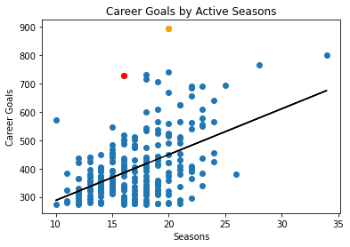

```python
# Get rows for Gretzky and Ovechkin so we can highlight them in the plots.
gretzky = goals[goals['Player'] == 'Wayne Gretzky']
ovechkin = goals[goals['Player'] == 'Alex Ovechkin']

# Generate goals scatterplot.
plt.scatter(goals['Seasons'], goals['G'])
plt.scatter(gretzky['Seasons'], gretzky['G'], color='orange')
plt.scatter(ovechkin['Seasons'], ovechkin['G'], color='red')
plt.title('Career Goals by Active Seasons')
plt.xlabel('Seasons')
plt.ylabel('Career Goals')

# Plot linear regression over scatterplot.
plt.plot(goals['Seasons'], reg.coef_ * goals['Seasons'] + reg.intercept_, color='black')

plt.show()
```

We can see that both Ovechkin and Gretzky are far above the regression line that was generated, so this model won't necessarily be accurate for either of them. Let's try to specifically predict Ovechkin's trajectory by fitting a regression specifically for him. Unfortunately, we lack the data on his career goals season-by-season, so the only points we have to generate the regression are (0, 0) and the one data point that represents his current career goals. This won't give us his current goal-scoring pace, but will give us a basic idea of his overall career goal-scoring pace, which could still prove useful to analyze.

We'll do this using a similar process as before.

```python
# Get the x- and y-axes for Ovechkin's trajectory.
ovi_x = np.array([0, goals[goals['Player'] == 'Alex Ovechkin']['Seasons'].values[0]]).reshape(-1, 1)
ovi_y = [0, goals[goals['Player'] == 'Alex Ovechkin']['G'].values[0]]

ovi_reg = LinearRegression().fit(ovi_x, ovi_y)
```

Let's plot the new regression line over top of the other one. We'll make it brown.

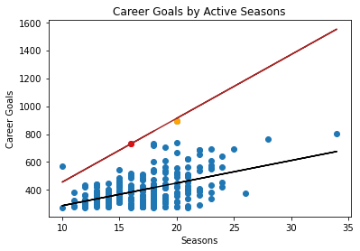

```python
# Get rows for Gretzky and Ovechkin so we can highlight them in the plots.
gretzky = goals[goals['Player'] == 'Wayne Gretzky']
ovechkin = goals[goals['Player'] == 'Alex Ovechkin']

# Generate goals scatterplot.
plt.scatter(goals['Seasons'], goals['G'])
plt.scatter(gretzky['Seasons'], gretzky['G'], color='orange')
plt.scatter(ovechkin['Seasons'], ovechkin['G'], color='red')
plt.title('Career Goals by Active Seasons')
plt.xlabel('Seasons')
plt.ylabel('Career Goals')

# Plot old linear regression over scatterplot.
plt.plot(goals['Seasons'], reg.coef_ * goals['Seasons'] + reg.intercept_, color='black')

# Plot new linear regression over scatterplot.
plt.plot(goals['Seasons'], ovi_reg.coef_ * goals['Seasons'] + ovi_reg.intercept_, color='brown')

plt.show()
```

The regression line that specifically tracks Ovechkin's trajectory allows us to see that his rate of goal attainment is higher than almost any other player in NHL history, as is supported by his number six all-time goals ranking and with the lowest number of seasons in the top ten. Ovechkin's regression line shows him surpassing Gretzky's goals record in his twentieth season.

## Conclusion

Although the above regression showing Ovechkin's overall career pace shows him dethroning Gretzky's goal record, the full story is a little more complicated. One factor we haven't discussed yet that needs to be taken into account is age. Ovechkin is currently 36 years old, and Gretzky retired at 38. The average NHL player retires in their late 20s, making Ovechkin's career significantly longer than that which is typical in the league. While his career is definitely on the shorter side of those reflected in the leaders dataset, he is approaching retirement age, which will likely make it difficult for him to keep up his goal-scoring pace. While he could edge out Gretzky if he played another four seasons at his overall career pace, the aging factor could make that less likely.

Again, this is looking at Gretzky's goal-scoring record alone. As we saw earlier, he stands alone in his assists and points records, and we only looked at three of his many records in any kind of depth in this tutorial. The fact that we can only compare Ovechkin to Gretzky in one dimension of his offensive power says a lot about the breadth of Gretzky's legacy in the NHL. While there is a chance that Ovechkin could take Gretzky's goal record by the time he retires, or at the very least approach it, he is not another Gretzky. There have been no other Gretzkys in NHL history, and there very well may never be another in its future. We just have to wait and see.

## Additional Links

If you would like to learn more about the tools used in this tutorial, here are the links to some helpful resources.

Requests documentation: https://docs.python-requests.org/en/master/index.html  
BeautifulSoup documentation: https://www.crummy.com/software/BeautifulSoup/bs4/doc/  
Pandas documentation: https://pandas.pydata.org/pandas-docs/stable/  
Numpy documentation: https://numpy.org/doc/  
--> More about NaN: https://www.askpython.com/python/examples/nan-in-numpy-and-pandas  
--> More about arrays: https://numpy.org/doc/stable/reference/generated/numpy.array.html  
Matplotlib documentation: https://matplotlib.org/  
Sklearn documentation: https://sklearn.org/documentation.html  
--> Linear regression documentation: https://scikit-learn.org/stable/modules/generated/sklearn.linear_model.LinearRegression.html